# stomatal anatomy microscopy imaging

Frank Wang

1/20/2024

### 1. Prepare

1.1 Find a mold folder and take out one working page.

1.2 Open the data file and find the number of the page.

For quantity test: https://docs.google.com/spreadsheets/d/166n-3RT2ai1lQwvxABFdsAe6WKWF4I5sx1N6Zqs4soU/edit?usp=drive_link

#where is the datasheet for each garden?

1.3 Open a blank page and record the same number on both two sides and all other information from the working page to the blank page.

1.4 Move all samples on side of the working page and place them in the preparation area (a shallow, gridded slab, or a plastic tray) according to their numbers.

1.5 Check that the sample is clean, could use paper towels to clean the surface.

### 2.Nail Polish

2.1 Open a bottle of nail polish and make sure the brush is clean and tidy first.

2.2 Apply an even coat of nail polish to each mold and put them back to the working place.

2.3 Wait for drying, about 5 minutes.

2.4 Apply the dried nail polish with tape and remove it from the mold

2.5 Apply tape and nail polish to the slide, make it flat.

### 3. Use a microscope to take stomatal images.

3.1. Computer and microscope

3.1.1 If the microscope has a cover, remove it carefully.

3.1.2 Open the light of the microscope.

3.1.3 Open the console power.

3.1.4 Turn the objective lens to 10X.

3.1.5 Open the NIS-Elements soft work on the computer.

3.2. Observation and Imaging

3.2.1 Place the prepared slide on the observation stage

3.2.2 Open live observation (Green arrow button)

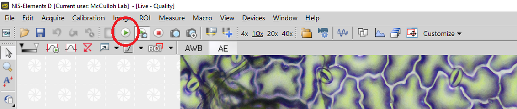

3.2.3 Open the AE control if not (Auto light control)

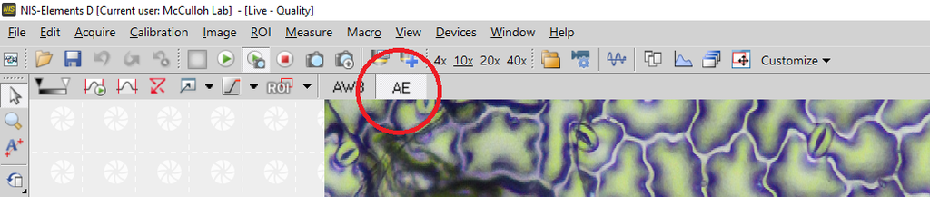

3.2.4 Adjust focus and position to find the right, clear image

```
  #Easy to see the stomata

  #The image should be bright, clear, and accurate focus

  #Not a lot of bubbles or trichomes
```

3.2.5 Resolution is 1280X960

```
    Acquire/setting
```

[figure not shown]

3.3 Use capture button take photo.

[figure not shown]

3.3.1 Use file label save image to the computer desktop

3.3.2 The file format is JEPG

```
YYYY_region_row_col_surface

OR

YYYY_region_row_col_surface_rep

Use _ or -, no whitespace

Always use lowercase

Column – always use three digits
```

Examples:

```
2023_north_101_001_upper

2023_north_101_001_upper_1
```

### 4. Final work

4.1 Upload the all images to the folder.

For quantity test: https://drive.google.com/drive/folders/1rGSGvlBm00Ye6gKyBNPd3TnKy1ifnGRN?usp=drive_link

For other data:

North 2023: https://drive.google.com/drive/folders/1Y4d_mS67HFyicTvW2c8bdpv8SuKld3cf?usp=drive_link

South 2023： https://drive.google.com/drive/folders/1iYK1C87dMIz8_xLXEpZffssG0rSQFYPU?usp=drive_link

4.2 Report the image information on the data file, including the time and name of the sampler.

4.3 Place the completed molds on a blank recording paper, secure them with tape again, and put it back to the folder.

4.4 Remove the tape and clean the slide with ethanol for next time.

4.5 Used tape can be thrown directly into the trash can

4.6 When done for the day, put all slides back to the box

4.7 Close the computer console, turn off the microscope light, and put the cover back

### Precautions

If the microscope is not used for a long time, turn off the power

Don’t disturb other people’s work.